# 206 Project

Author

Yifan Wu

Published

November 30, 2024

# Principal Component Analysis(PCA)

## The Introduction of PCA

When understanding feature extraction and processing, problems involving high-dimensional feature vectors are often prone to **dimensional disasters**. As the dimensionality of the dataset increases, the number of samples required for algorithm learning increases exponentially.

PCA is commonly used for exploring and visualizing high-dimensional data-sets; It can also be used for data compression, data pre-processing, etc. PCA can synthesize high-dimensional variables that may have correlation into linearly independent low dimensional variables, known as principal components.

## The Principle of PCA Method

PCA projects data onto a **low dimensional subspace** to achieve dimensionality reduction.

For example, dimensionality reduction in a 2 dimensional data-set is to project the surface into a line, and each sample in the data-set can be represented by a value on the line, without the need for two values on the surface. This achieves the operation of reducing data from 2 dimensional to 1 dimensional.

In general, an n-dimensional data-set can be reduced to a k-k-dimensional subspace through mapping, where k ≤ n.

Assuming we have a 2 dimensional data-set as shown in the following figure, each sample in the data-set is represented by two variables.

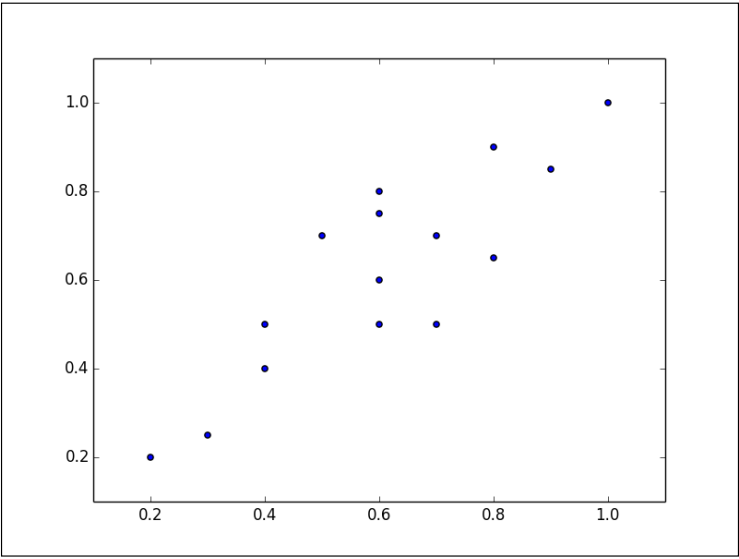

To reduce the dimensionality of the entire dataset, we must map the points into a line. The two lines in the following figure can be mapped by the dataset. Which line does the sample change the most when mapped to?

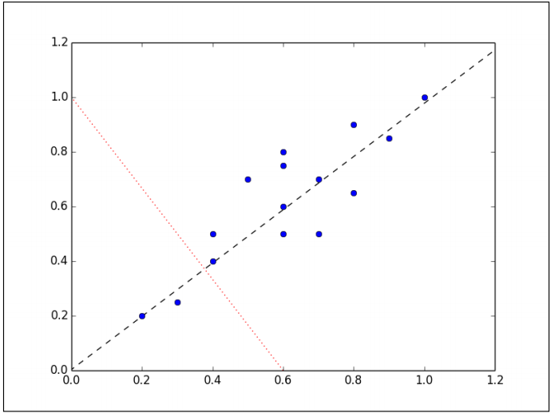

Obviously, the change in mapping the sample to the black dashed line is much greater than the change in mapping to the red dotted line. In fact, this black dashed line is the first principal component. The second principal component must be orthogonal to the first principal component, as shown in the following figure:

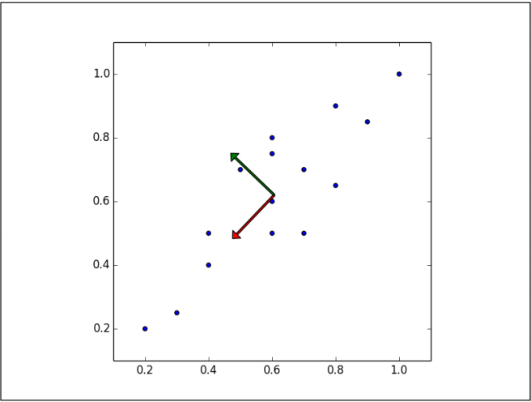